# Graphs in R using ggplot2: Bland-Altman Plots

⇦ Back

> This tutorial is about *plotting* Bland-Altman graphs. For a more complete tutorial on Bland-Altman analysis as a whole, see here. For a tutorial on scatter plots in general, see here and, for line plots in general, see here.

**Bland-Altman plots** are used to assess the agreement between two methods of measuring something, usually clinical information. They were discussed in Bland & Altman’s 1986 paper (available [here](https://www-users.york.ac.uk/~mb55/meas/ba.pdf) and/or [here](https://pubmed.ncbi.nlm.nih.gov/2868172/)) and see also the [Wikipedia page](https://en.wikipedia.org/wiki/Bland%E2%80%93Altman_plot). Here is the example data that was used in the 1986 paper in **data frame** format:

```r
# Peak expiratory flow rate measurements made using a Wright peak flow meter
# and a mini Wright peak flow meter
# - https://www-users.york.ac.uk/~mb55/datasets/pefr.dct
# - https://www-users.york.ac.uk/~mb55/datasets/datasets.htm
# - https://www-users.york.ac.uk/~mb55/meas/ba.pdf
df <- data.frame(
    `Wright Mini` = c(
        512, 430, 520, 428, 500, 600, 364, 380, 658,
        445, 432, 626, 260, 477, 259, 350, 451
    ),
    `Wright Large` = c(
        494, 395, 516, 434, 476, 557, 413, 442, 650,
        433, 417, 656, 267, 478, 178, 423, 427
    ),
    check.names = FALSE
)
```

This data shows the maximum speed of expiration (the ‘peak expiratory flow rate’, or PEFR) of 17 people. It was collected using two different measurement devices: a large and a mini Wright peak flow meter.

# 1 Value-Value Plot

The data can be plotted as a scatter graph:

- Import the ggplot library with `library(ggplot2)`
- Create the plot area with the `ggplot()` function and the data frame `df` that we created above. You will also need to create an aesthetic mapping with the `aes()` function
- Assign this plot to a variable. In this example, we’ve chosen `p` as our variable.
- Even though you’ve created a plot area and defined a data frame with x- and y-data, the points will not yet be *on* the plot. They need to be added to `p` explicitly with the `geom_point()` function.
- Display the graph by calling `print()` on the plot `p`

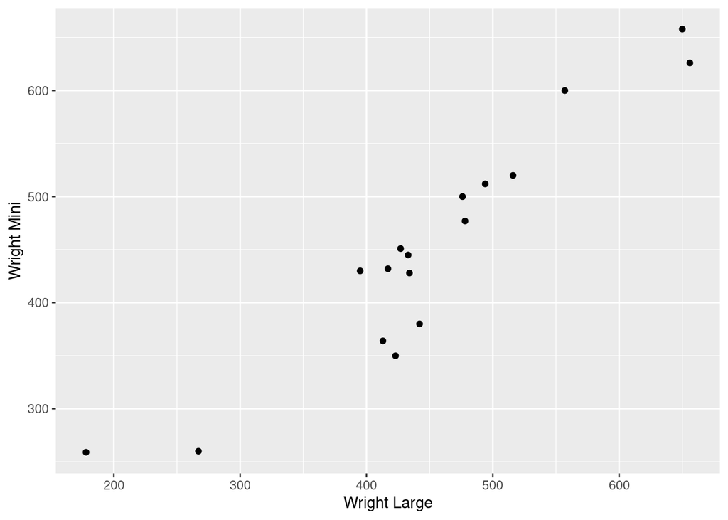

```r
library(ggplot2)

p <- ggplot(df, aes(x = `Wright Large`, y = `Wright Mini`))
p <- p + geom_point()

print(p)
```

Add a title and axis labels with `ggtitle()`, `xlab()` and `ylab()`:

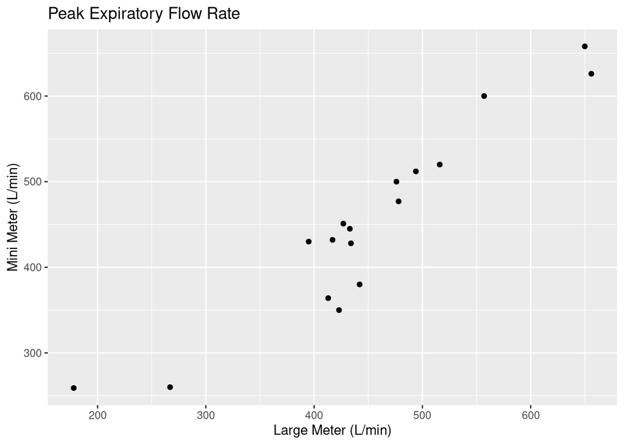

```r
p <- p + ggtitle("Peak Expiratory Flow Rate")
p <- p + ylab("Mini Meter (L/min)")
p <- p + xlab("Large Meter (L/min)")

print(p)
```

Now let’s add a **line of equality**. This shows *ideal agreement*: the closer the points are to the line the better the two measurement methods agree with each other.

- Add a `geom_abline()` to get a straight line, specifying an `intercept` and a `slope` (a ‘gradient’ for non-Americans)
- Get the maximum values of the data you are plotting using the `max()` function then set the axis limits to be 10% larger than this using `ylim()` and `xlim()`

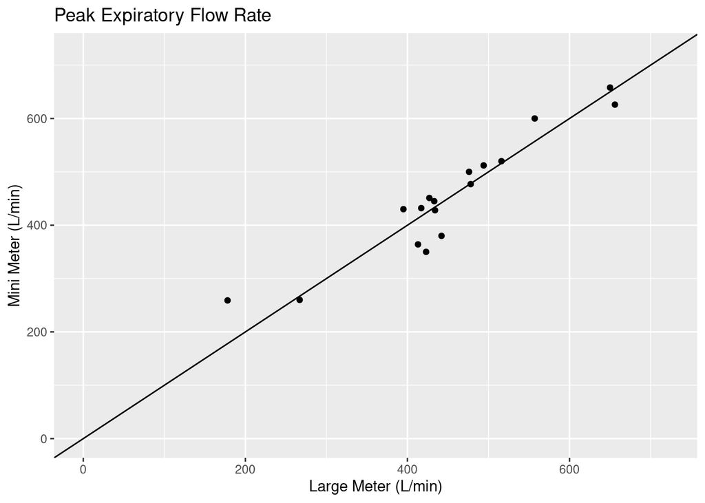

```r
# Plot the line of equality
p <- p + geom_abline(intercept = 0, slope = 1)
# Set the axis limits
top <- max(df["Wright Mini"])
right <- max(df["Wright Large"])
p <- p + ylim(0, top * 1.1)
p <- p + xlim(0, right * 1.1)

print(p)
```

Finally, let’s make some aesthetic improvements:

- Change the marker shape, colour, transparency, fill colour and size using *keyword arguments* inside the `geom_point()` function:
  - `shape` changes the marker **shape**, see all the available options here
  - `col` changes the **colour**
  - `alpha` changes the **transparency**
  - `bg` changes the background colour of the marker (aka the **fill colour**)
  - `size` changes the marker **size**
- Change the **aspect ratio** with `coord_fixed()`. The default is to make the axes square, but this can be customised with the `ratio` keyword argument

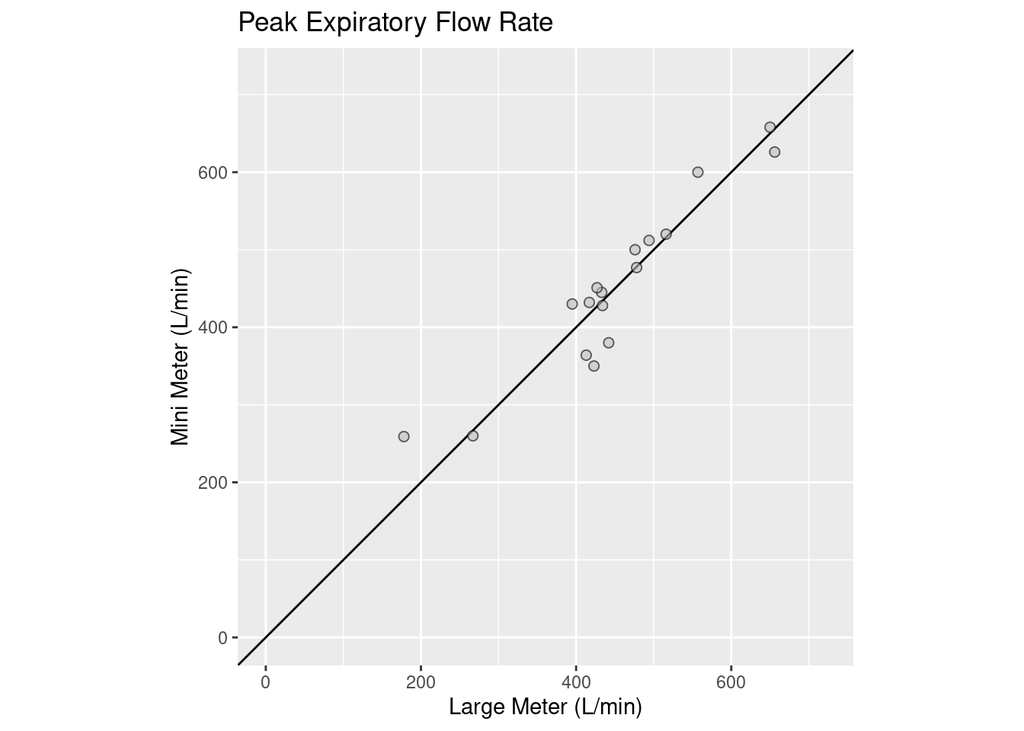

```r
p <- ggplot(df, aes(x = `Wright Large`, y = `Wright Mini`))
# Plot the line of equality
p <- p + geom_abline(intercept = 0, slope = 1)
# Scatter plot
p <- p + geom_point(shape = 21, col = "black", alpha = 0.6, bg="grey", size = 2)
# Title and labels
p <- p + ggtitle("Peak Expiratory Flow Rate")
p <- p + ylab("Mini Meter (L/min)")
p <- p + xlab("Large Meter (L/min)")
# Set the axis limits
top <- max(df["Wright Mini"])
right <- max(df["Wright Large"])
p <- p + ylim(0, top * 1.1)
p <- p + xlim(0, right * 1.1)
# Set the aspect ratio
p <- p + coord_fixed()

print(p)
```